# Assignment Machine Learning

Patrick

2024-11-10

## Summary

### The goal of this project was to predict the manner in which the participants did the exercise.A training set was used to train different model.

### The best model with the highest accuracy was a combined model of a “random forest” and a “gradient boosting”.

### The model was applied on the testing set to determine in what manner the participants did the exercise.

### Load and clean data:

```r
training_url <- "https://d396qusza40orc.cloudfront.net/predmachlearn/pml-training.csv"
testing_url <- "https://d396qusza40orc.cloudfront.net/predmachlearn/pml-testing.csv"
training <- read.csv(training_url, header=TRUE)
testing <- read.csv(testing_url, header = TRUE)
dim(training) ; dim(testing)
```

```
## [1] 19622   160
```

```
## [1]  20 160
```

```r
training$classe <- as.factor(training$classe) #change classe variable to factor

#clean up
#sum(is.na(training))
training_old <- training

#Filter out all columns that have NAs
training <- select(training, - which(is.na(training[1,])))
#sum(is.na(training)) #no more NAs in training set

#process testing data set by removing all NAs
testing <- select(testing, - which(is.na(training_old[1,])) )
#sum(is.na(testing))
testing <- select(testing, - which(is.na(testing[1,])))
#names(testing) #this leaves 60 variables for our model

#now we apply this selection to the training set
training <- training[, intersect(names(training), names(testing))]
training$classe <- training_old$classe
testing <- testing[, intersect(names(training), names(testing))]
#dim(training)
#dim(testing)

training <- select(training,-X,  - user_name,-raw_timestamp_part_1,-raw_timestamp_part_2,-cvtd_timestamp,-num_window, -new_window )
testing <- select(testing,-X,  - user_name,-raw_timestamp_part_1,-raw_timestamp_part_2,-cvtd_timestamp,-num_window, -new_window )

print(dim(training))
```

```
## [1] 19622    53
```

```r
print(dim(testing))
```

```
## [1] 20 52
```

```r
#this leaves 53 columns for training and 52 for testing
```

### After the removal of NAs and unnecessary varibales, we have 53 columns for the training set and 52 columns (no classe column) for the testing set.

### Next, we need to partition the training data set to generate a validation test set.

```r
set.seed(123)
inTrain <- createDataPartition(y = training$classe, p = 0.75, list = FALSE)
training <- training[inTrain,]
validation <- training[-inTrain,]
dim(training); dim(validation)
```

```
## [1] 14718    53
```

```
## [1] 3699   53
```

### Now, we will test two different models: “Random Forest” and “Gradient Boosting”.

### Additionally, we will create “Recursive Partitioning and Regression Trees” using “rpart”.

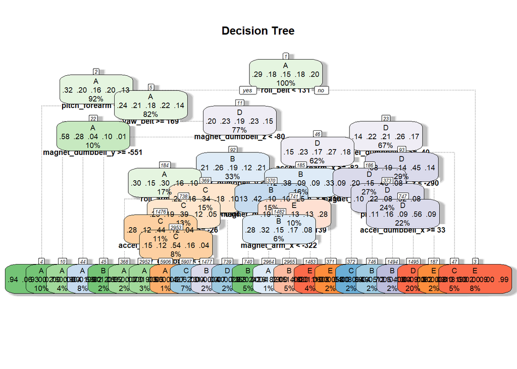

```r
train_ex <- training[abs(runif(1000, 1, length(training[,1]))),]
validation_ex<- validation[abs(runif(1000,1,length(validation[,1]))),]

rpart <- rpart(classe~., data = train_ex, method = "class")
fancyRpartPlot(rpart, main="Decision Tree", sub="", cex = 0.6 )
```

```r
rf <- train(classe ~ ., data=train_ex, method = "rf", prox=TRUE)
pred_rf <- predict(rf, validation_ex)
Accuracy_rf <- confusionMatrix(pred_rf, validation_ex$classe)$overall["Accuracy"]
#print(Accuracy_rf)

gbm <- train(classe ~ ., data=train_ex, method="gbm", verbose=FALSE)
pred_gbm <- predict(gbm, validation_ex)
Accuracy_gbm <- confusionMatrix(pred_gbm, validation_ex$classe)$overall["Accuracy"]
#print(Accuracy_gbm)

predDF <- data.frame(pred_rf, pred_gbm, validation_ex$classe)
combModFit <- train(validation_ex.classe ~., method = "rf", data = predDF)
combPred <- predict(combModFit, predDF)
Accuracy_all <- confusionMatrix(combPred, validation_ex$classe)$overall["Accuracy"]
#print(Accuracy_all)
```

### The accuracy of the two models and the combined model is:

```r
paste("Random Forest: ",Accuracy_rf)
```

```
## [1] "Random Forest:  0.92"
```

```r
paste("Gradient Boosting: ", Accuracy_gbm)
```

```
## [1] "Gradient Boosting:  0.903"
```

```r
paste("Combined Model: ", Accuracy_all )
```

```
## [1] "Combined Model:  0.935"
```

### Therefore, the combined model shows the highest accuracy and will be used on the testing set.

### The out of sample error is:

```r
# What is the out of sample error?
out_of_sample_error <- 1 - Accuracy_all
paste("Out of sample error is: ", out_of_sample_error)
```

```
## [1] "Out of sample error is:  0.0649999999999999"
```

### Using the combined model on the testing data set:

```r
pred_rf_test <- predict(rf, testing)
pred_gbm_test <- predict(gbm, testing)

predDF_test <- data.frame(pred_rf = pred_rf_test, pred_gbm = pred_gbm_test)
head(predDF_test)
```

```
##   pred_rf pred_gbm
## 1       B        B
## 2       A        A
## 3       A        B
## 4       A        A
## 5       A        A
## 6       E        E
```

```r
classe_predictions <- predict(combModFit, predDF_test)
print(classe_predictions)
```

```
##  [1] B A A A A E D B A A D A B A E E A B A B
## Levels: A B C D E
```

```r
writeFiles = function(x){
  n = length(x)
  for(i in 1:n){
    filename = paste0("problem_id_",i,".txt")
    write.table(x[i],file=filename,quote=FALSE,row.names=FALSE,col.names=FALSE)
  }
}

writeFiles(classe_predictions)
```